# Lab 1

## Excercise 4

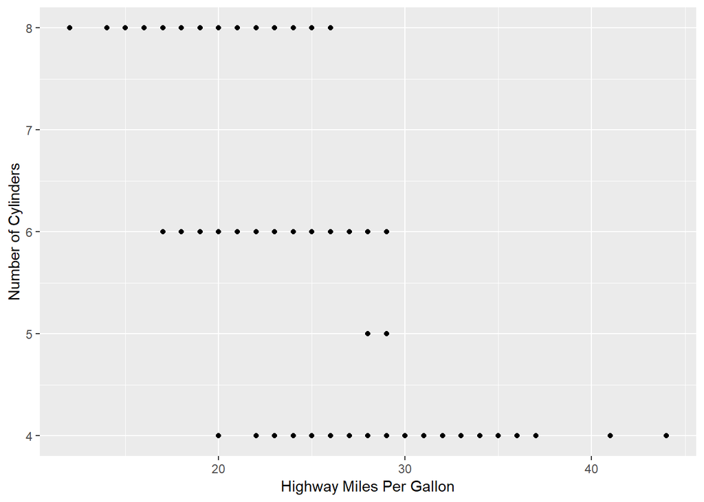

```r
ggplot(data=mpg,aes(x=hwy,y=cyl)) +
  geom_point() +
  xlab("Highway Miles Per Gallon") +
  ylab("Number of Cylinders")
```

## Excercise 5

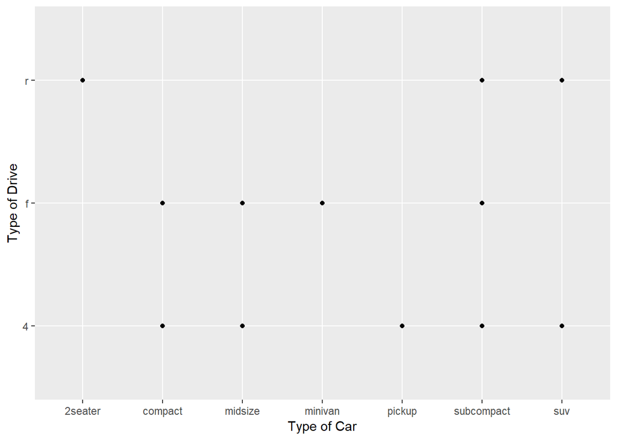

```r
ggplot(data=mpg,aes(x=class,y=drv)) +
  geom_point() +
  xlab("Type of Car") +
  ylab("Type of Drive")
```

Scatter plots are not meant to visualize the relationship between two categorical/qualitative variables.

# Chapter 1 (Pg. 12)

## Exercise 1

What’s gone wrong with this code? Why are the points not blue?  
The color property must be set outside of aes (see code below).

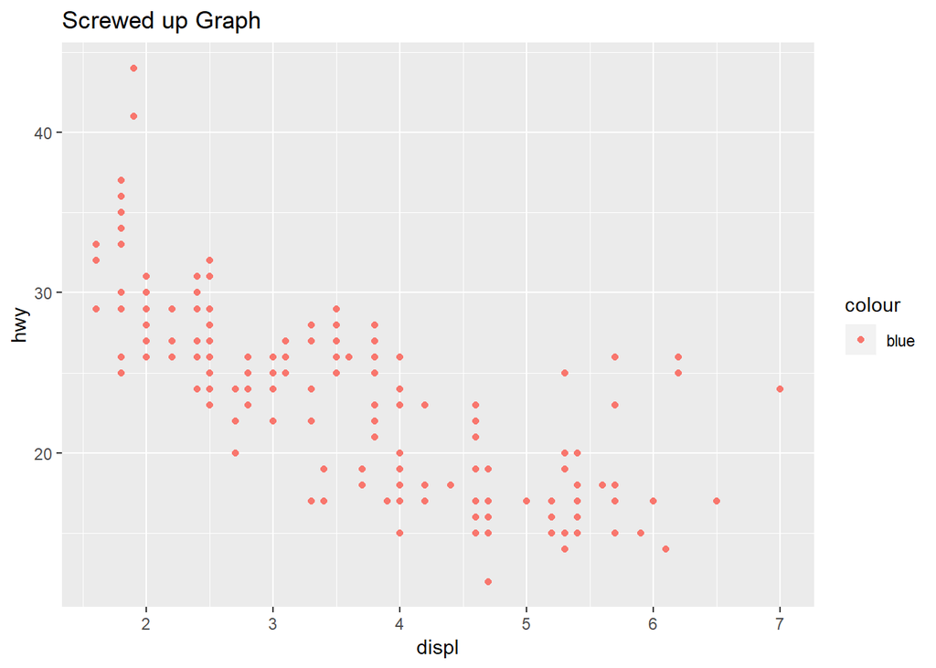

```r
# --> Original graph
ggplot(data=mpg) +
  geom_point(
    mapping = aes(x = displ, y = hwy, color = "blue")
  ) +
  ggtitle("Screwed up Graph")
```

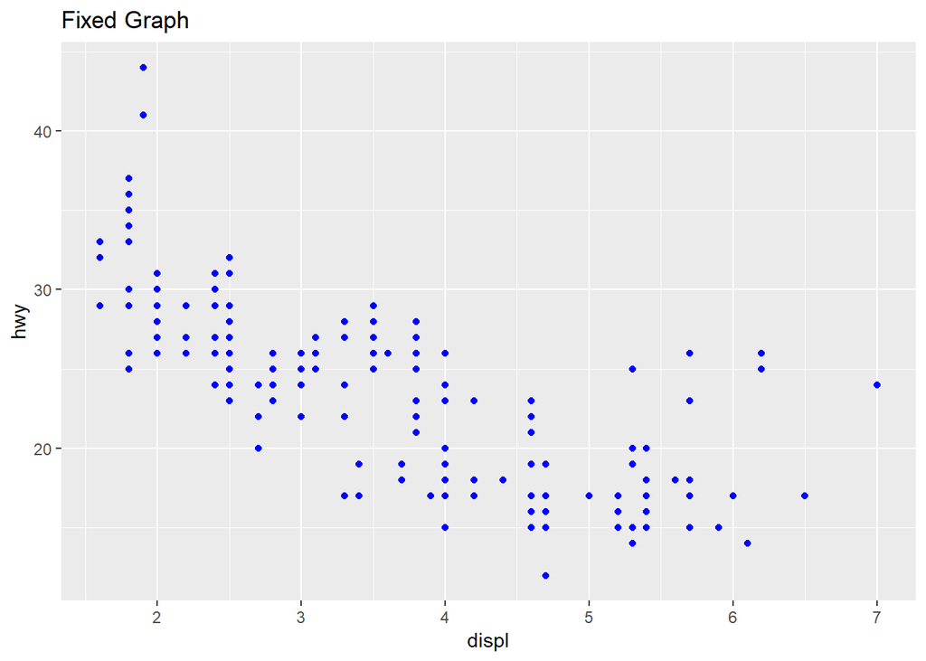

```r
# --> Fixed graph
ggplot(data=mpg) +
  geom_point(
    mapping = aes(x = displ, y = hwy), color = "blue"
  ) +
  ggtitle("Fixed Graph")
```

## Exercise 2

Which variables in mpg are categorical?

Categorical variables: - manufacturer - model - trans - drv - fl - class

```r
?mpg
```

```
## starting httpd help server ... done
```

```r
#--> Check by looking at variables:
head(mpg)
```

```
## # A tibble: 6 x 11
##   manufacturer model displ  year   cyl trans drv     cty   hwy fl    class
##   <chr>        <chr> <dbl> <int> <int> <chr> <chr> <int> <int> <chr> <chr>
## 1 audi         a4      1.8  1999     4 auto~ f        18    29 p     comp~
## 2 audi         a4      1.8  1999     4 manu~ f        21    29 p     comp~
## 3 audi         a4      2    2008     4 manu~ f        20    31 p     comp~
## 4 audi         a4      2    2008     4 auto~ f        21    30 p     comp~
## 5 audi         a4      2.8  1999     6 auto~ f        16    26 p     comp~
## 6 audi         a4      2.8  1999     6 manu~ f        18    26 p     comp~
```

```r
#--> Conclusion:
# The six variables listed above are the categorical variables.
```

## Exercise 5

What does the stroke aesthetic do? What shape does it work with?

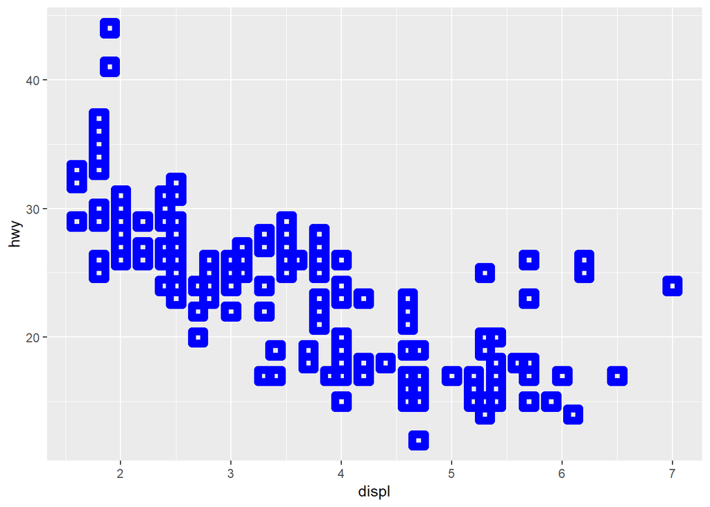

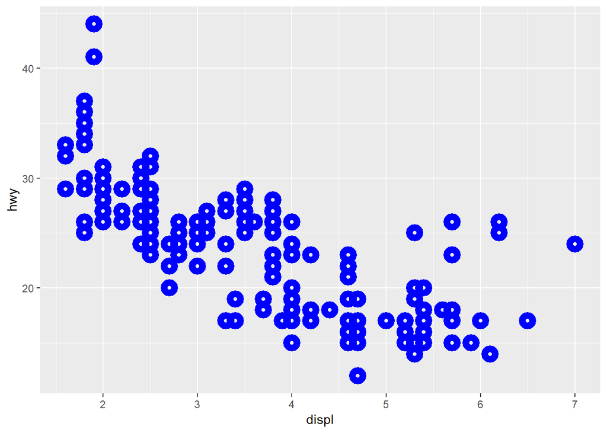

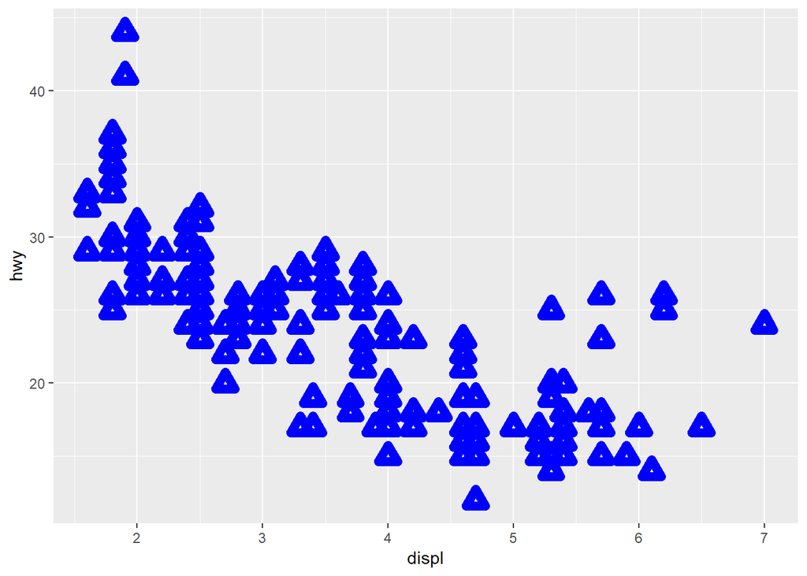

```r
#--> Familiarize with geom_point
?geom_point

#--> Graph a sample graph with some of the 20 shapes:
for(i in 0:2){
  print(ggplot(data=mpg) +
        geom_point(
        mapping = aes(x = displ, y = hwy), color = "blue",  shape = i, stroke = 4
        )
  )
}
```